```python
import numpy as np
import matplotlib.pyplot as plt
from scipy.stats import beta, gamma, uniform, norm, chi2
```

# Question 7.1

Let $X = Z^{2}$ where $Z\sim \mathcal{N}(0,1)$ is the standard normal. The random variable $X$ has a chi-squared distribution with 1 degree of freedom (Gamma(1/2, 1/2)). For each of the following problems, calculate the answer in the following two ways:

A) Using Monte Carlo methods, sampling from a standard normal distribution, and taking the number of samples equal to $10^{k}$ for each value $k=2,4,6.$

B) Using the appropriate built-in functions from your prefered computational tool.

Compare the results of the various computations

i) Plot the pdf of the random variable X (experiment to find a good number of bins for your histogram)

ii) Compute the c.d.f. $F_{X}(x)$ for $x\in \{0.5, 1.0, 1.5\}$

iii) Compute the expected value $\mathbb{E}[X]$

iv) Compute the variance Var $(X)$.

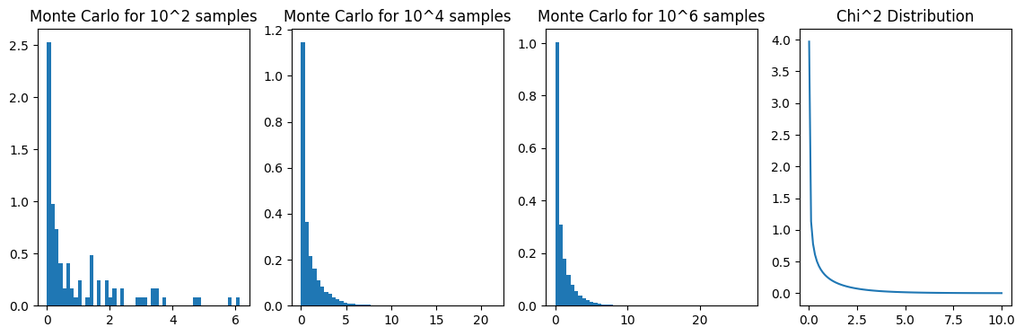

```
First three values represent Monte Carlo Estimates and last value is the actual
cdf for x = 0.5 [0.57, 0.5244, 0.519301, 0.5204998778130466]
cdf for x = 1.0 [0.67, 0.6802, 0.681575, 0.5204998778130466]
cdf for x = 1.5 [0.77, 0.7755, 0.778174, 0.5204998778130466]
expected values [0.9842416899906884, 0.9930152938833995, 1.004160843582151, 1.0]
variance values [1.779034601036848, 1.9161108307463772, 2.012835300094552, 2.0]
```

```python
# Part (i) Plot the pdf of the random variable X
# iterate through subplots for each n value

samples = []

for i, n in enumerate([2, 4, 6]):   # i=index, n=num of samples
    plt.subplot(1,4,i+1)
    plt.title("Monte Carlo for 10^" + str(n) + " samples")

    sample = np.random.normal(0, 1, 10**n)**2
    plt.hist(sample, bins=50, density=True)

    samples.append(sample)

x = np.linspace(0.01, 10, 100)

plt.subplot(1,4,4)
plt.title("Chi^2 Distribution")
plt.plot(x, chi2.pdf(x, 1))
plt.gcf().set_size_inches(14, 4)
plt.show()

samples = np.array(samples)
cdf_k_2 = []
cdf_k_4 = []
cdf_k_6 = []

# Computing the cdf for 0.5, 1.0 and 1.5
for x in [0.5, 1.0, 1.5]:
    cdf_k_2.append(np.mean(samples[0] <= x, axis=0))
    cdf_k_4.append(np.mean(samples[1] <= x, axis=0))
    cdf_k_6.append(np.mean(samples[2] <= x, axis=0))

print("First three values represent Monte Carlo Estimates and last value is the actual")

# Printing the cdfs for each x value
print(f"cdf for x = 0.5 {[cdf_k_2[0], cdf_k_4[0], cdf_k_6[0], chi2.cdf(0.5, 1)]}")
print(f"cdf for x = 1.0 {[cdf_k_2[1], cdf_k_4[1], cdf_k_6[1], chi2.cdf(0.5, 1)]}")
print(f"cdf for x = 1.5 {[cdf_k_2[2], cdf_k_4[2], cdf_k_6[2], chi2.cdf(0.5, 1)]}")

# Compute the expected value E[X]
expected = []
expected.append(samples[0].mean(axis=0))
expected.append(samples[1].mean(axis=0))
expected.append(samples[2].mean(axis=0))
expected.append(chi2.mean(1))
print(f"expected values {expected}")

# Compute variance
variance = []
variance.append(samples[0].var(axis=0))
variance.append(samples[1].var(axis=0))
variance.append(samples[2].var(axis=0))
variance.append(chi2.var(1))
print(f"variance values {variance}")
```

# Question 7.2

Write code to approximate $\pi$ using the Monte Carlo methods in the reading, by sampling pairs from the uniform distribution on $[-1,1]\times [-1,1]$ and counting the proportion that lie inside the circle $x^2 + y^2 \leq 1$. Sample $10^k$ times for $k\in\{2,4,6\}$ and compare the results to the true value of $\pi.$ Calculate the (approximate) standard error for each of these estimates.

```python
for i, k in enumerate([2, 4, 6]):
    sample = np.random.uniform(-1, 1, size=(10**k, 2))
    circle_vals = sample[:, 0]**2 + sample[:, 1]**2 <= 1
    circle_vals_4 = circle_vals * 4

    print(f"Percent in circle for k = 10^{k}: {np.mean(circle_vals)}")
    print(f"Approximation to pi for k = 10^{k}: {np.mean(circle_vals) * 4}")
    print(f"Approximate standard error for k = 10^{k}: {np.std(circle_vals_4, ddof=1) / np.sqrt(len(circle_vals_4))}\n")
```

```
Percent in circle for k = 10^2: 0.78
Approximation to pi for k = 10^2: 3.12
Approximate standard error for k = 10^2: 0.16653327995729064

Percent in circle for k = 10^4: 0.7908
Approximation to pi for k = 10^4: 3.1632
Approximate standard error for k = 10^4: 0.01627031186870216

Percent in circle for k = 10^6: 0.785383
Approximation to pi for k = 10^6: 3.141532
Approximate standard error for k = 10^6: 0.0016422263515981554
```

# Question 7.3

There are at least two different Monte Carlo methods you could use to approximate the area under the curve $y = e^{\text{cos}(x^2)}$ for $x\in [0,2]$.

i) Estimate the integral \begin{equation} \int_{0}^{2}h(x)dx = 2* \int_{0}^{2}h(x)f_{\text{Uniform}([0,2])}(x)dx = 2\mathbb{E}[h\circ X] \end{equation} by approximating $\mathbb{E}[h\circ X]$, with sampling from the Uniform$([0,2])$ at least $10^5$. What is the (approximate value of the) standard error?

ii) Estimate the area under the curve by taking a 2d-sample \begin{equation} Z \sim \text{Uniform}([0,2]) \times \text{Uniform}([0,b]) \end{equation} for some $b$ with $b\geq \text{max}_{x\in [0,2]}e^{\text{cos}(x^2)}$ and then count (and scale appropriately) the samples that lie under the curve. This corresponds to estimating a multiple of $\mathbb{E}[k\circ Z]$, where $k=\mathbb{1}_{A}$ and $A=\{(x,y) | 0 \leq y\leq e^{\text{cos}(x^2)}\}$. Sample at least $5 \times 10^4$ times. What is the (approximate value of the) standard error?

Compare the results of the two methods.

```python
h = lambda x: np.exp(np.cos(x**2))
domain = np.linspace(0, 2, 1000)

# Part 1 Using the expected value
sample = np.random.uniform(0, 2, 10**5)
expected = np.sum(h(sample)) / (10**5)
integral_h = 2 * expected
std_err = np.std(h(sample), ddof=1) / np.sqrt(10**5)
print(f"Standard error from part i) {std_err}")

# Part 2 Using area
max = np.max(h(domain))
sample = np.random.uniform([0, 0], [2, max], size=(5*10**4, 2))
points_under_curve = (sample[:, 1] <= h(sample[:, 0])) * (2 * max)
std_err = np.std(points_under_curve, ddof=1) / np.sqrt(5*10**4)
print(f"Standard error from part iI) {std_err}")
```

```
Standard error from part i) 0.002983747310491108
Standard error from part iI) 0.011933694768871414
```

# Question 7.4

Use Monte Carlo methods to estimate the probability that a sample from Beta(2,5) will be less than a sample from Beta(20,55). How many samples are required to give 95% confidence that your answer is correct to three decimals places?

```python
n = 10**6 + 1

# Take samples from the different beta distributions
sample_1 = np.random.beta(2, 5, n)
sample_2 = np.random.beta(20, 55, n)

# Boolean mask the numpy array to find which values are less than the second
under = sample_1 < sample_2

# Take the standard error
std_err = np.std(under, ddof=1) / np.sqrt(n)

print(f"In order to get a 95% confidence level you will need around {n} samples to get a standard error of about {std_err} and avoid rounding issues")
```

```
In order to get a 95% confidence level you will need around 1000001 samples to get a standard error of about 0.000499999940707865 and avoid rounding issues
```

# Question 7.5

Consider a game where you roll a fair four-sided die with sides labeled \$1, 2, 3, \text{ and } 4$. You win \$1 if the die shows 1 or 2, you win \$2 if the die shows 3, and you lose $1 if the die shows 4. Use Monte Carlo simulation methods to estimate the probability that your winnings will be negative after 10 rolls of the die. Justify your choice of the number of samples to use.

```python
def run_game(num):
    possibilities = [1, 2, 3, 4]
    mapping = {1:1, 2:1, 3:2, 4:-1}
    game = np.random.choice(possibilities, num)
    winnings = np.vectorize(mapping.__getitem__)(game)
    return np.sum(winnings) < 0

n = 10**5

run_game_array = np.ones(n, dtype=int) * 10
win_count = np.vectorize(run_game)
run_game_array = win_count(run_game_array)

prob_lose = np.sum(run_game_array) / n
std_err = np.std(run_game_array, ddof=1) / np.sqrt(n)
print(f"The probability of negative winnings with {n} rolls is: {prob_lose}")
print(f"The standard error is: {std_err} which has a 95% confidence interval to justify the number of samples")
```

```
The probability of negative winnings with 100000 rolls is: 0.01347
The standard error is: 0.0003645365823469556 which has a 95% confidence interval to justify the number of samples
```